# CE4073 : Assignment 1

Nurhaqim Bin Mohammad

U1621026J

### Analysis of Energy Efficiency

Task 1: Perform a detailed exploratory data analysis and regression model building based on assign1_EnergyData.csv

Import the CSV data file `assign1_EnergyData.csv` for analysis, and quickly check the structure of the data.

```r
energyData <- read.csv("assign1_EnergyData.csv", header = TRUE)
str(energyData)
```

```
## 'data.frame':    700 obs. of  10 variables:
##  $ Compactness: num  0.74 0.9 0.79 0.69 0.82 0.98 0.69 0.62 0.62 0.66 ...
##  $ SurfaceArea: num  686 564 637 735 612 ...
##  $ WallArea   : num  245 318 343 294 318 ...
##  $ RoofArea   : num  220 122 147 220 147 ...
##  $ Height     : num  3.5 7 7 3.5 7 7 3.5 3.5 3.5 3.5 ...
##  $ Orientation: int  2 5 3 5 5 4 2 4 3 3 ...
##  $ GlazingArea: num  0.4 0.1 0 0.4 0.1 0.25 0.25 0.1 0.1 0.25 ...
##  $ GAreaDist  : int  3 4 0 3 5 5 3 5 2 1 ...
##  $ HeatingLoad: num  14 29.8 29.9 14.1 23.9 ...
##  $ CoolingLoad: num  16.1 29.9 31.3 17 27.7 ...
```

The following table summarizes the variables in the dataset. The table below shows the complete data description on the building.

| Variable | Description | Numeric / Categorical |
| --- | --- | --- |
| Compactness | Index of compactness ratio for the building | Categorical |
| SurfaceArea | Surface area of the complete building | Numeric |
| WallArea | Total surface area of the Walls of the building | Numeric |
| RoofArea | Total surface area of the Roof(s) of the building | Numeric |
| Height | Overall height of the building | Numeric |
| Orientation | Orientation of the building in terms of direction | Categorical |
| GlazingArea | Total area of Glazing around the building | Numeric |
| GAreaDist | Distribution of the Glazing Area in the building | Categorical |
| HeatingLoad | Total heating load required for the building | Numeric |
| CoolingLoad | Total cooling load required for the building | Numeric |

To start, get the first few rows of data and display it.

```r
head(energyData)
```

```
##   Compactness SurfaceArea WallArea RoofArea Height Orientation GlazingArea
## 1        0.74       686.0    245.0   220.50    3.5           2        0.40
## 2        0.90       563.5    318.5   122.50    7.0           5        0.10
## 3        0.79       637.0    343.0   147.00    7.0           3        0.00
## 4        0.69       735.0    294.0   220.50    3.5           5        0.40
## 5        0.82       612.5    318.5   147.00    7.0           5        0.10
## 6        0.98       514.5    294.0   110.25    7.0           4        0.25
##   GAreaDist HeatingLoad CoolingLoad
## 1         3       13.97       16.08
## 2         4       29.79       29.92
## 3         0       29.90       31.27
## 4         3       14.08       17.02
## 5         5       23.86       27.69
## 6         5       28.15       30.00
```

The first few values of the Heating Load and Cooling Load data shows that the minimum value is at around 13. The sixth value shows that that the value is about 30.

Next, get the last few rows of data and display it.

```r
tail(energyData)
```

```
##     Compactness SurfaceArea WallArea RoofArea Height Orientation
## 695        0.62       808.5    367.5    220.5    3.5           5
## 696        0.69       735.0    294.0    220.5    3.5           4
## 697        0.62       808.5    367.5    220.5    3.5           5
## 698        0.64       784.0    343.0    220.5    3.5           2
## 699        0.86       588.0    294.0    147.0    7.0           4
## 700        0.90       563.5    318.5    122.5    7.0           3
##     GlazingArea GAreaDist HeatingLoad CoolingLoad
## 695        0.25         4       14.65       15.38
## 696        0.25         1       12.73       15.48
## 697        0.40         2       17.15       16.99
## 698        0.25         4       16.99       19.65
## 699        0.25         5       28.31       34.15
## 700        0.25         4       31.69       37.12
```

The last few rows shows that the maximum value of Cooling Load and Heating Load is around between 30 - 40. This means that the sixth value almost reaches the maximum value.

Then , get the summary of the data.

```r
summary(energyData)
```

```
##   Compactness      SurfaceArea       WallArea        RoofArea
##  Min.   :0.6200   Min.   :514.5   Min.   :245.0   Min.   :110.2
##  1st Qu.:0.6900   1st Qu.:612.5   1st Qu.:294.0   1st Qu.:147.0
##  Median :0.7400   Median :686.0   Median :318.5   Median :220.5
##  Mean   :0.7633   Mean   :672.4   Mean   :318.1   Mean   :177.1
##  3rd Qu.:0.8200   3rd Qu.:735.0   3rd Qu.:343.0   3rd Qu.:220.5
##  Max.   :0.9800   Max.   :808.5   Max.   :416.5   Max.   :220.5
##      Height      Orientation     GlazingArea       GAreaDist
##  Min.   :3.50   Min.   :2.000   Min.   :0.0000   Min.   :0.000
##  1st Qu.:3.50   1st Qu.:3.000   1st Qu.:0.1000   1st Qu.:2.000
##  Median :3.50   Median :3.000   Median :0.2500   Median :3.000
##  Mean   :5.24   Mean   :3.499   Mean   :0.2355   Mean   :2.807
##  3rd Qu.:7.00   3rd Qu.:4.250   3rd Qu.:0.4000   3rd Qu.:4.000
##  Max.   :7.00   Max.   :5.000   Max.   :0.4000   Max.   :5.000
##   HeatingLoad     CoolingLoad
##  Min.   : 6.01   Min.   :10.90
##  1st Qu.:13.01   1st Qu.:15.64
##  Median :18.77   Median :21.84
##  Mean   :22.22   Mean   :24.51
##  3rd Qu.:31.28   3rd Qu.:32.92
##  Max.   :43.10   Max.   :48.03
```

Based on the summary table above, the minimum total amount of heating load required for the building is 6.01 and the maximum value is 43.10. While the minimum total amount of cooling load is 10.90 and the maximum value is 48.03.

Now, viewing the exploratiory data of individaul variables

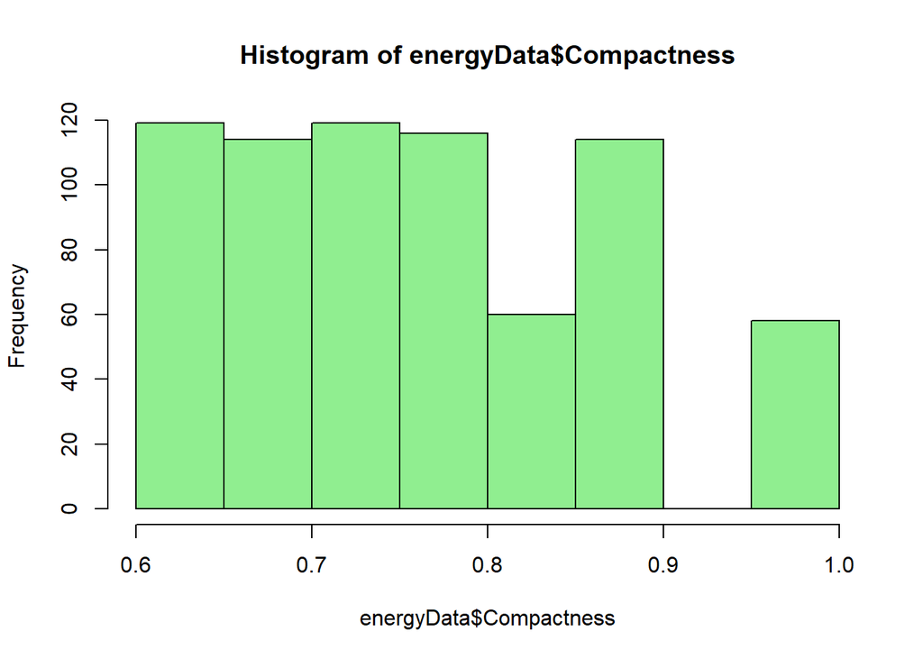

```r
hist(energyData$Compactness, col = "lightgreen")
```

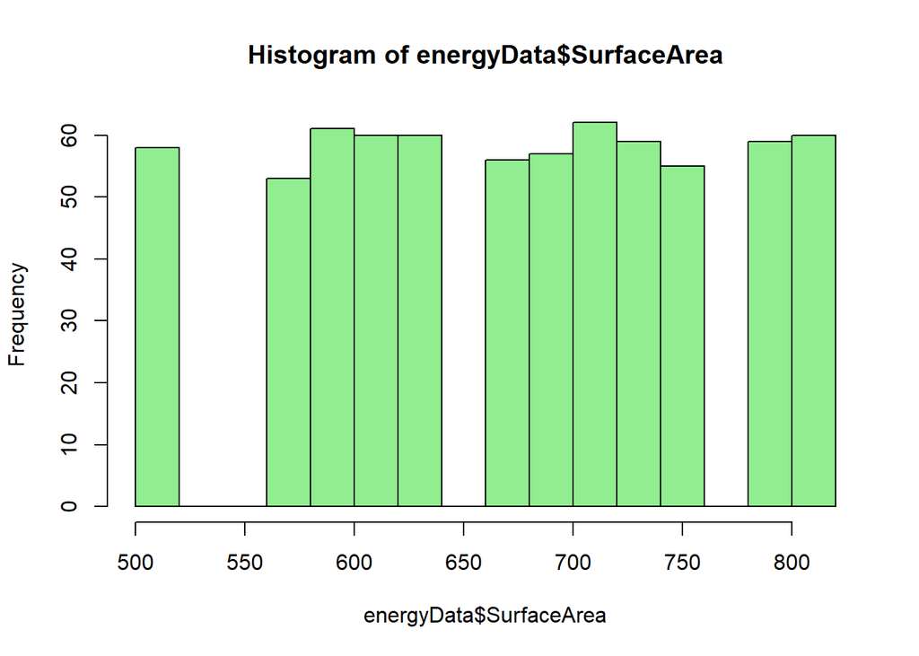

```r
hist(energyData$SurfaceArea, col = "lightgreen")
```

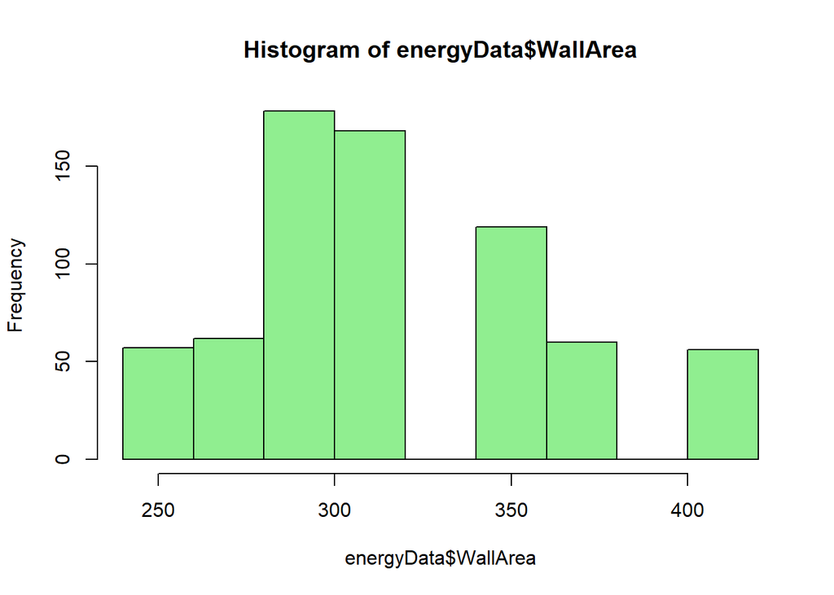

```r
hist(energyData$WallArea, col = "lightgreen")
```

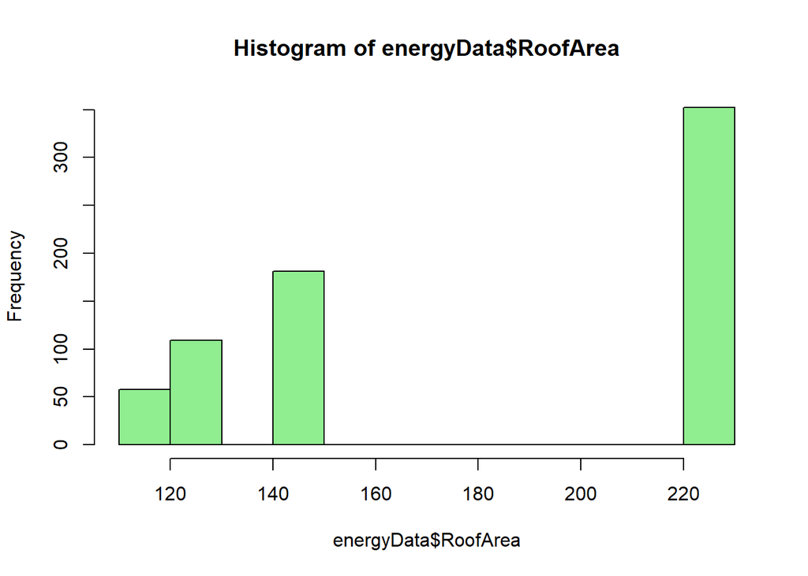

```r
hist(energyData$RoofArea, col = "lightgreen")
```

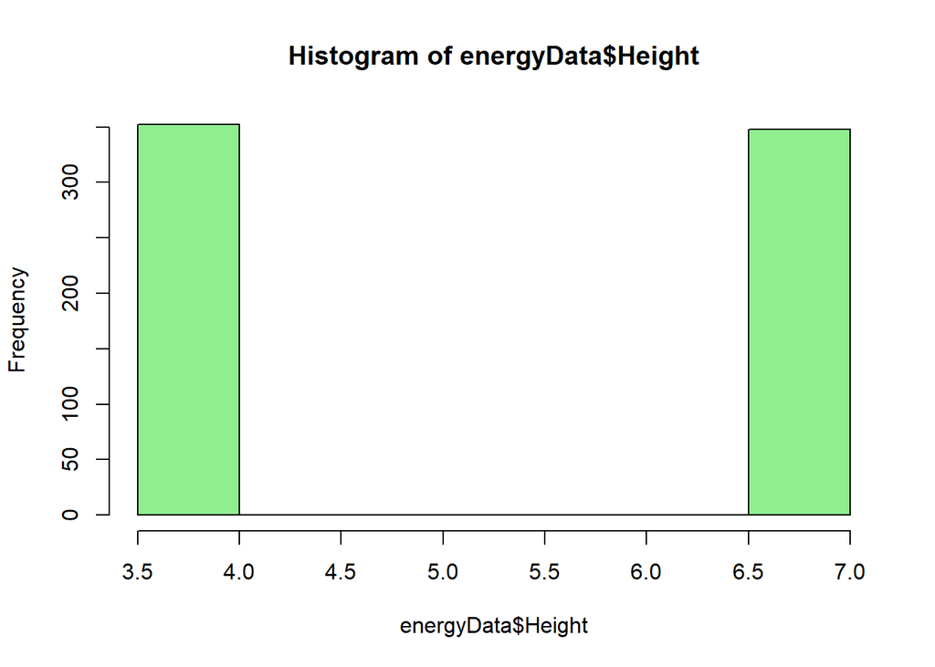

```r
hist(energyData$Height, col = "lightgreen")
```

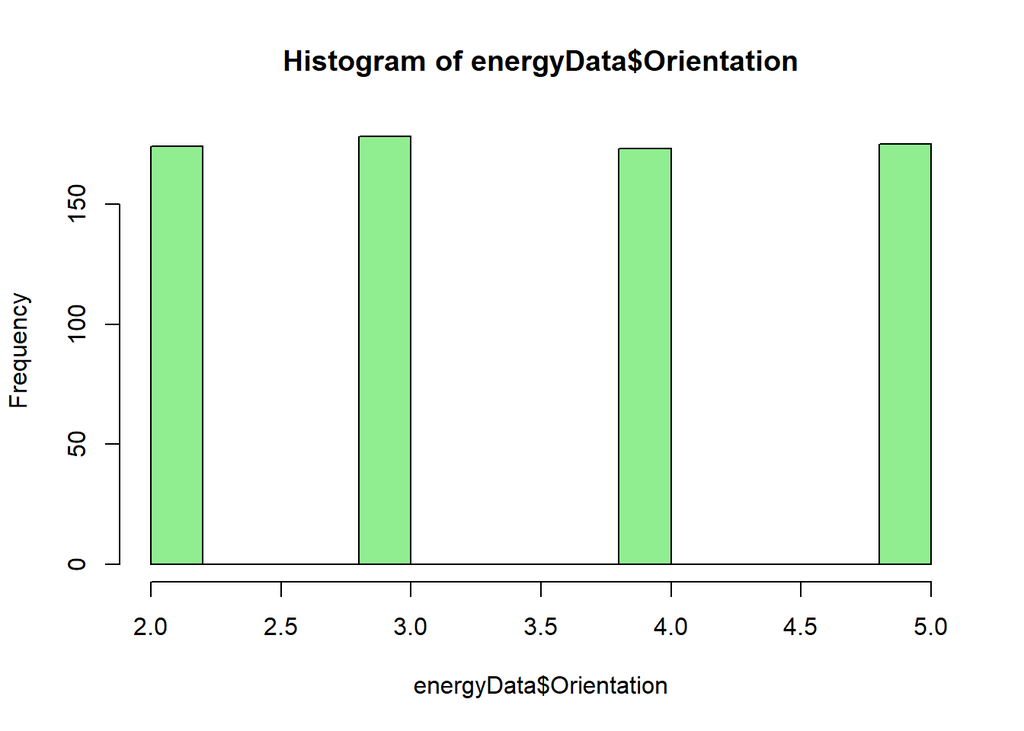

```r
hist(energyData$Orientation, col = "lightgreen")
```

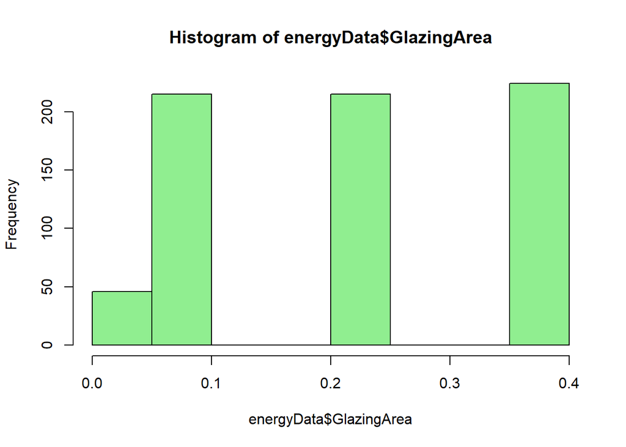

```r
hist(energyData$GlazingArea, col = "lightgreen")
```

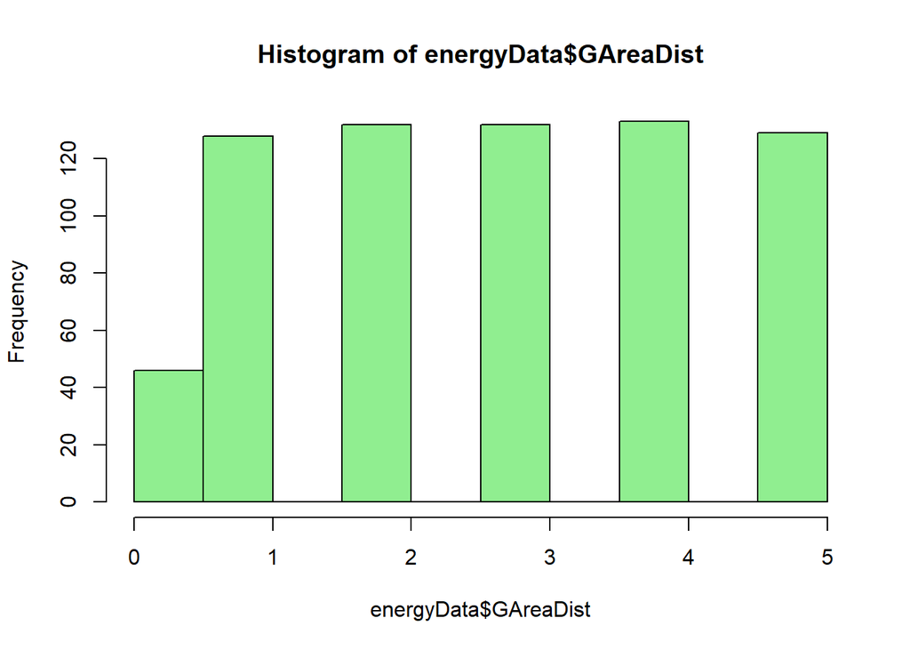

```r
hist(energyData$GAreaDist, col = "lightgreen")
```

Next, view the Exploratory Data Plots of in histogram of two variables(HeatingLoad and CoolingLoad)

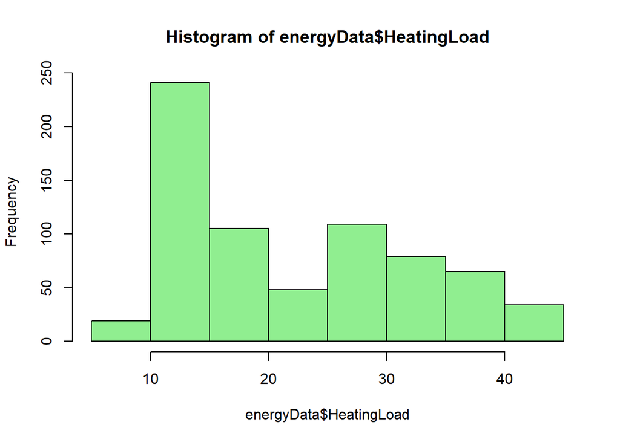

```r
hist(energyData$HeatingLoad, col = "lightgreen")
```

Upon inspection, the heating load histogram frequency is increasing drastically, then the frequency went down at a stable state.

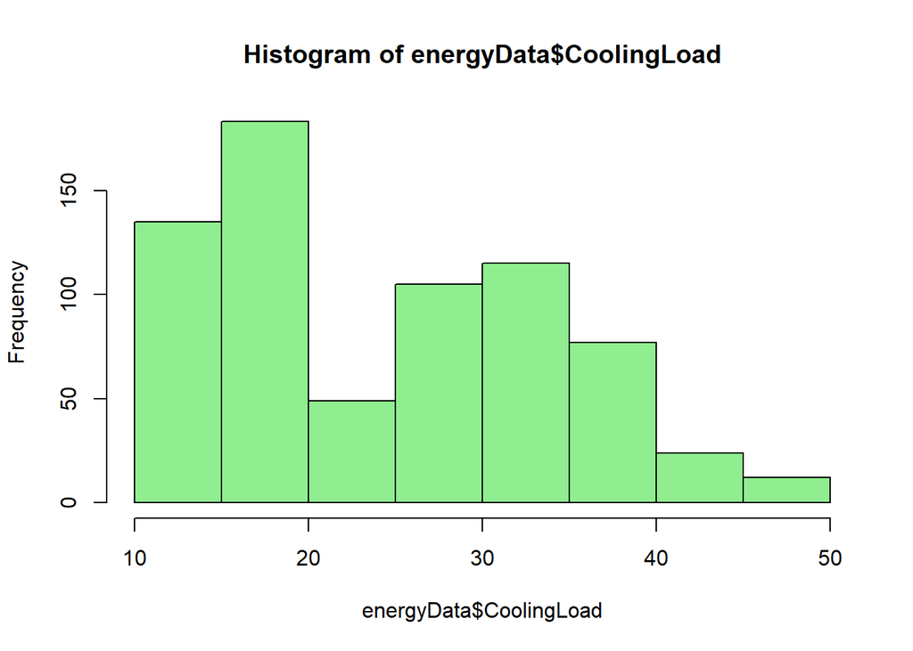

```r
hist(energyData$CoolingLoad, col = "lightgreen")
```

The cooling load histogram frequency increase slightly then start decreasing to a lower frequency level.

By inspection of two histogram, the heating load histogram is almost the same way as the cooling load histogram.

However, try checking on the data in boxplot to see the frequency of the variables.

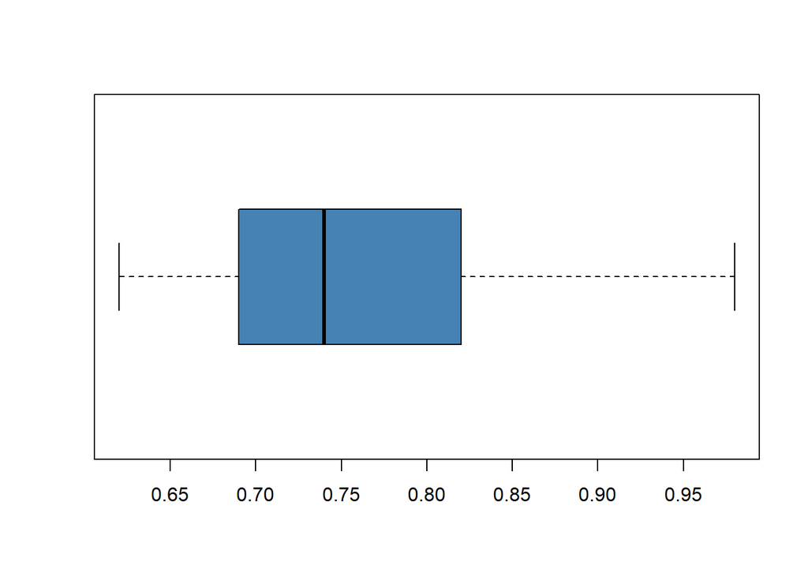

```r
boxplot(energyData$Compactness, horizontal = TRUE, col = "steelblue")
```

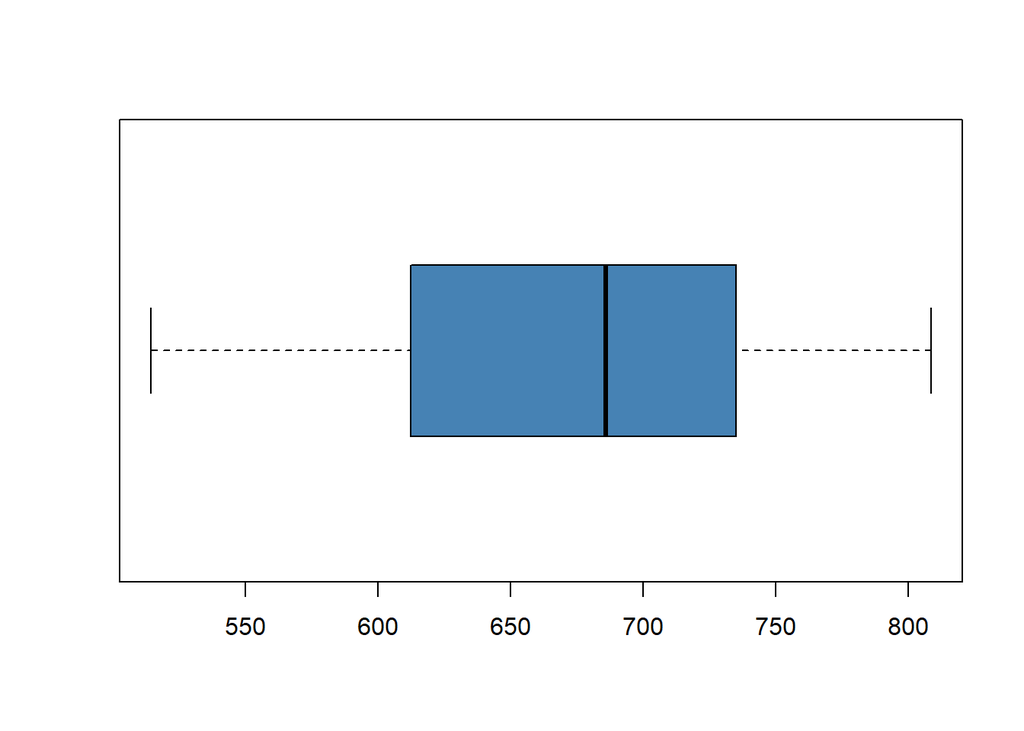

```r
boxplot(energyData$SurfaceArea, horizontal = TRUE, col = "steelblue")
```

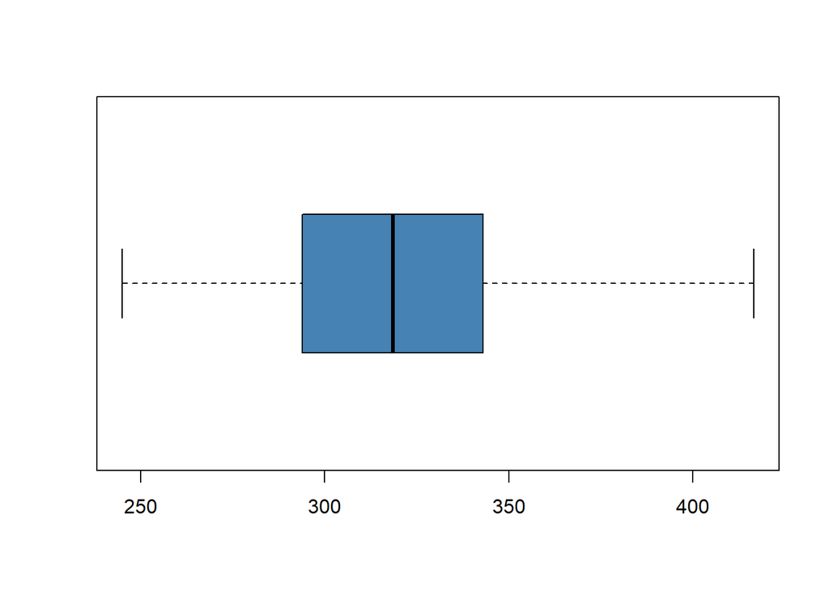

```r
boxplot(energyData$WallArea, horizontal = TRUE, col = "steelblue")
```

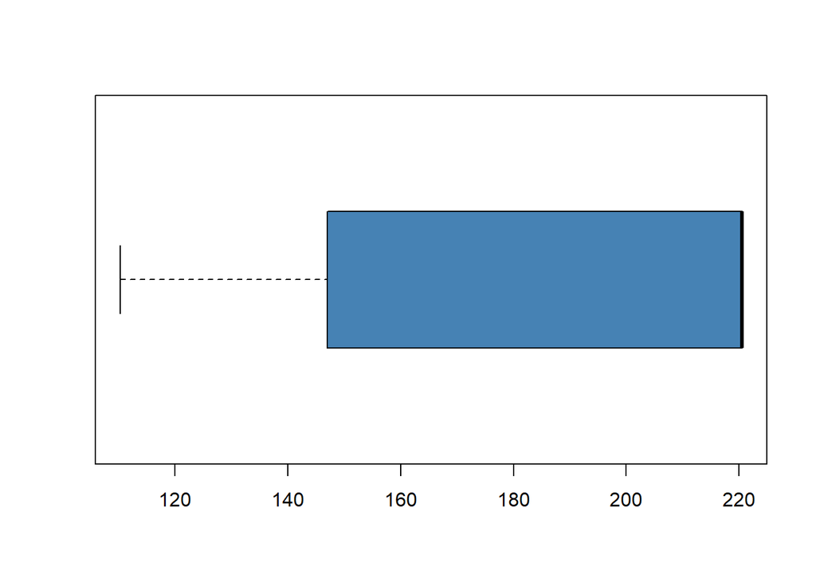

```r
boxplot(energyData$RoofArea, horizontal = TRUE, col = "steelblue")
```

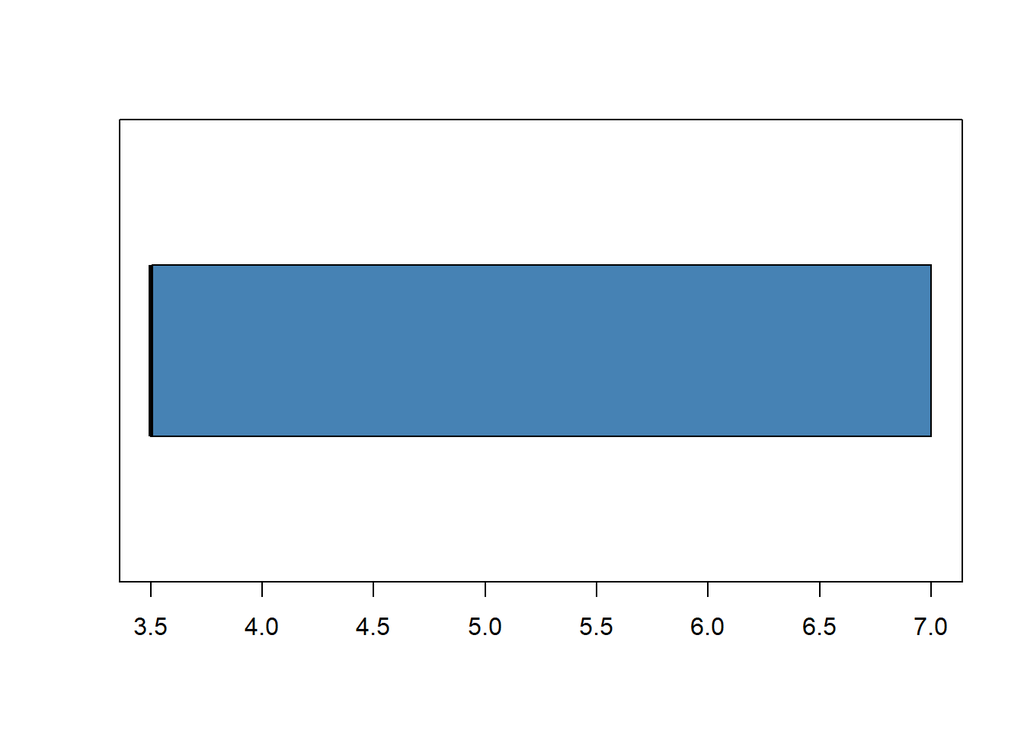

```r
boxplot(energyData$Height, horizontal = TRUE, col = "steelblue")
```

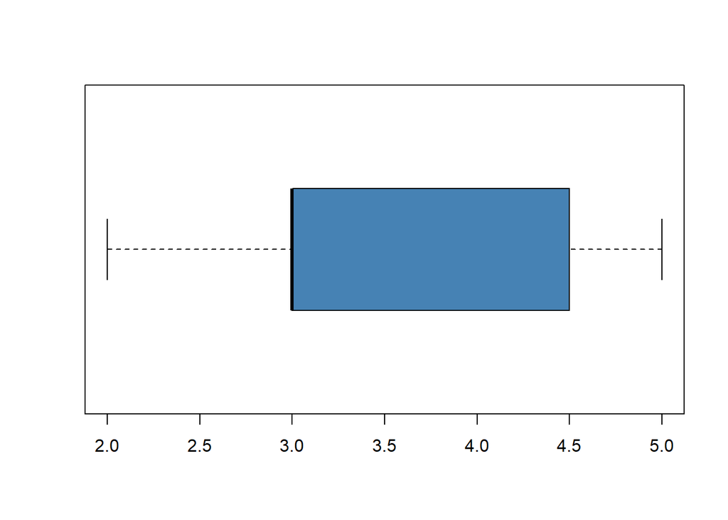

```r
boxplot(energyData$Orientation, horizontal = TRUE, col = "steelblue")
```

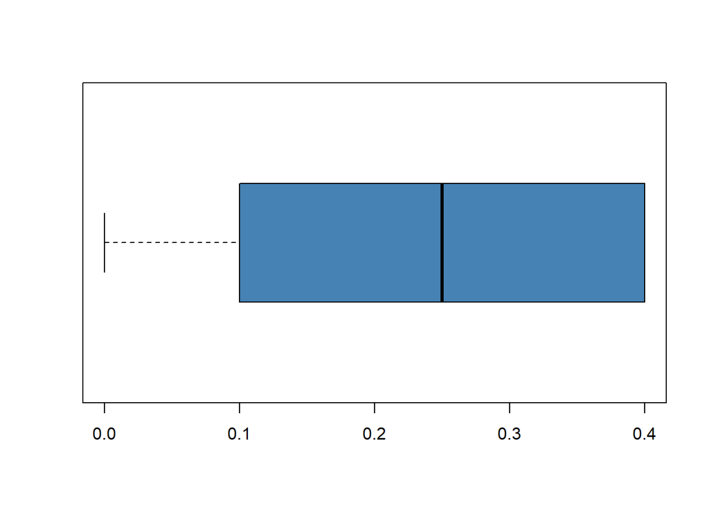

```r
boxplot(energyData$GlazingArea, horizontal = TRUE, col = "steelblue")
```

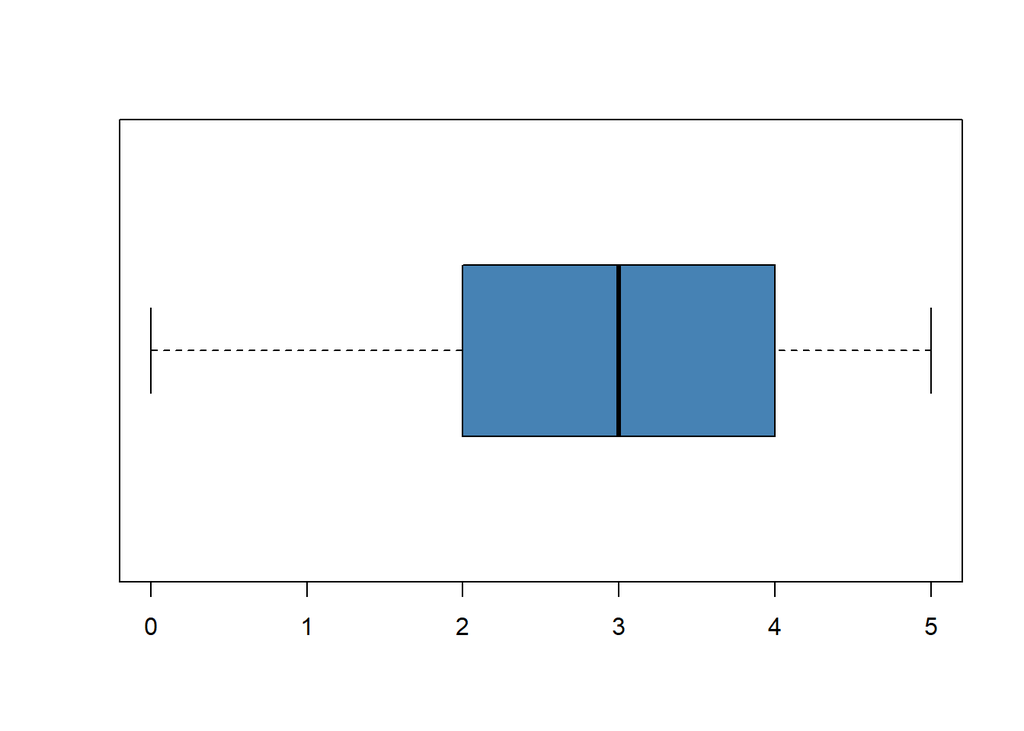

```r
boxplot(energyData$GAreaDist, horizontal = TRUE, col = "steelblue")
```

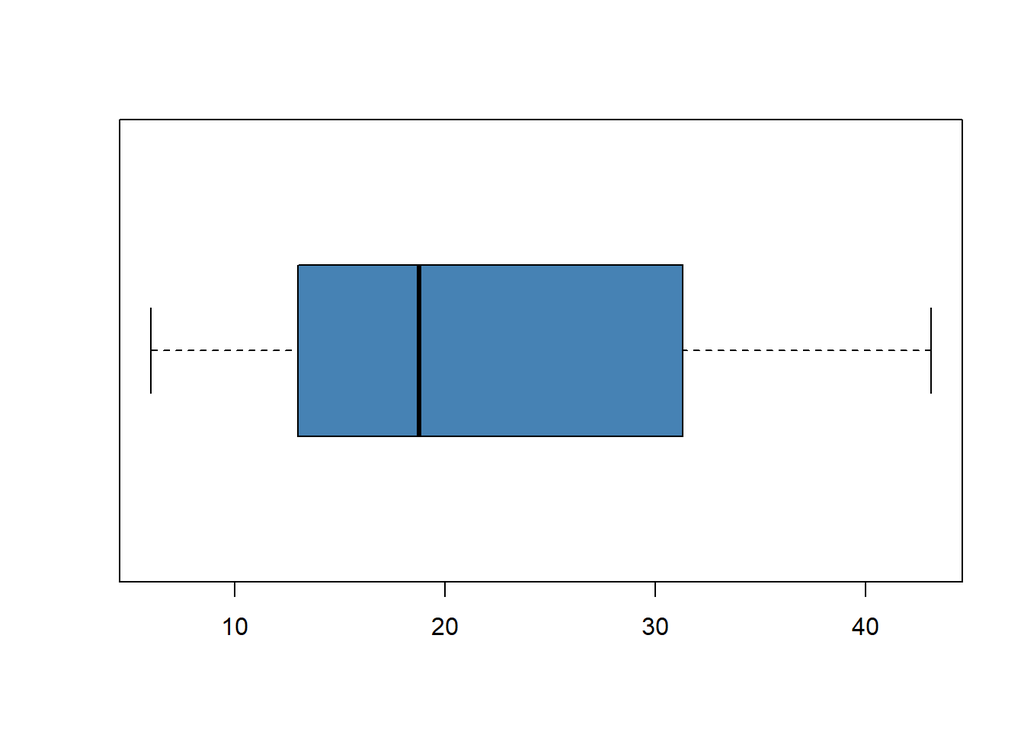

```r
boxplot(energyData$HeatingLoad, horizontal = TRUE, col = "steelblue")
```

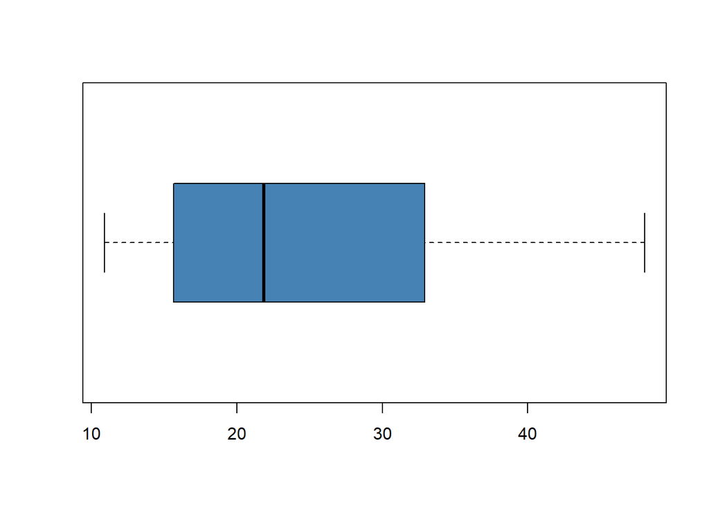

```r
boxplot(energyData$CoolingLoad, horizontal = TRUE, col = "steelblue")
```

The results in boxplot shows the same way as the histogram but with a slightly clear view.

Now, by doing linear regression of the two variables, HeatingLoad and CoolingLoad for further analysis.

Perform linear regression on cooling Load vs all others to find the best model

```r
lmFitCool1 <- lm(CoolingLoad ~ . , data = energyData)
summary(lmFitCool1)
```

```
##
## Call:
## lm(formula = CoolingLoad ~ ., data = energyData)
##
## Residuals:
##     Min      1Q  Median      3Q     Max
## -4.9035 -1.0880 -0.1327  0.9823  7.1206
##
## Coefficients: (1 not defined because of singularities)
##               Estimate Std. Error t value Pr(>|t|)
## (Intercept)  25.986119  13.372904   1.943  0.05240 .
## Compactness -15.134137   7.333557  -2.064  0.03942 *
## SurfaceArea  -0.014315   0.012054  -1.188  0.23540
## WallArea     -0.007019   0.004877  -1.439  0.15060
## RoofArea            NA         NA      NA       NA
## Height        0.638497   0.255885   2.495  0.01282 *
## Orientation   0.111496   0.065858   1.693  0.09091 .
## GlazingArea  -2.404590   0.750846  -3.203  0.00142 **
## GAreaDist    -0.140692   0.049268  -2.856  0.00442 **
## HeatingLoad   0.862216   0.024919  34.601  < 2e-16 ***
## ---
## Signif. codes:  0 '***' 0.001 '**' 0.01 '*' 0.05 '.' 0.1 ' ' 1
##
## Residual standard error: 1.945 on 691 degrees of freedom
## Multiple R-squared:  0.9584, Adjusted R-squared:  0.9579
## F-statistic:  1990 on 8 and 691 DF,  p-value: < 2.2e-16
```

Names to access regression

```r
names(lmFitCool1)
```

```
##  [1] "coefficients"  "residuals"     "effects"       "rank"
##  [5] "fitted.values" "assign"        "qr"            "df.residual"
##  [9] "xlevels"       "call"          "terms"         "model"
```

Building updated Model by removing Orientation, compactness and RoofArea variable

```r
lmFitCool2 <- update(lmFitCool1, ~ . - Orientation - Compactness - RoofArea - HeatingLoad, data = energyData)
 summary(lmFitCool2)
```

```
##
## Call:
## lm(formula = CoolingLoad ~ SurfaceArea + WallArea + Height +
##     GlazingArea + GAreaDist, data = energyData)
##
## Residuals:
##     Min      1Q  Median      3Q     Max
## -8.3934 -2.0676  0.1395  1.5843 11.3875
##
## Coefficients:
##               Estimate Std. Error t value Pr(>|t|)
## (Intercept) -31.526093   3.854700  -8.179 1.37e-15 ***
## SurfaceArea   0.024150   0.005947   4.061 5.45e-05 ***
## WallArea      0.018681   0.006425   2.907  0.00376 **
## Height        5.762535   0.304028  18.954  < 2e-16 ***
## GlazingArea  14.791918   0.956516  15.464  < 2e-16 ***
## GAreaDist     0.061475   0.082786   0.743  0.45799
## ---
## Signif. codes:  0 '***' 0.001 '**' 0.01 '*' 0.05 '.' 0.1 ' ' 1
##
## Residual standard error: 3.297 on 694 degrees of freedom
## Multiple R-squared:  0.8799, Adjusted R-squared:  0.879
## F-statistic:  1017 on 5 and 694 DF,  p-value: < 2.2e-16
```

For the linear regression, orientation, compactness, RoofArea and Glazing Area Distribution are not suitable for producing meaningful results.

```r
 lmFitCool3 <- update(lmFitCool2, ~ . - GAreaDist - Height + I(SurfaceArea^2), data = energyData)
summary(lmFitCool3)
```

```
##
## Call:
## lm(formula = CoolingLoad ~ SurfaceArea + WallArea + GlazingArea +
##     I(SurfaceArea^2), data = energyData)
##
## Residuals:
##     Min      1Q  Median      3Q     Max
## -7.5960 -1.8367 -0.8931  1.2103 12.8302
##
## Coefficients:
##                    Estimate Std. Error t value Pr(>|t|)
## (Intercept)      -8.237e+01  8.030e+00  -10.26   <2e-16 ***
## SurfaceArea       2.768e-01  2.393e-02   11.57   <2e-16 ***
## WallArea          1.326e-01  3.152e-03   42.07   <2e-16 ***
## GlazingArea       1.521e+01  9.914e-01   15.34   <2e-16 ***
## I(SurfaceArea^2) -2.719e-04  1.793e-05  -15.16   <2e-16 ***
## ---
## Signif. codes:  0 '***' 0.001 '**' 0.01 '*' 0.05 '.' 0.1 ' ' 1
##
## Residual standard error: 3.518 on 695 degrees of freedom
## Multiple R-squared:  0.863,  Adjusted R-squared:  0.8622
## F-statistic:  1094 on 4 and 695 DF,  p-value: < 2.2e-16
```

```r
cd <- cooks.distance(lmFitCool3)
 energyData.clean <- energyData[abs(cd) < 4/nrow(energyData), ]
 nrow(energyData.clean)
```

```
## [1] 662
```

```r
formula(lmFitCool3)
```

```
## CoolingLoad ~ SurfaceArea + WallArea + GlazingArea + I(SurfaceArea^2)
```

```r
lmFitCool <- lm(formula(lmFitCool3), data = energyData.clean)
```

```r
summary(lmFitCool)
```

```
##
## Call:
## lm(formula = formula(lmFitCool3), data = energyData.clean)
##
## Residuals:
##     Min      1Q  Median      3Q     Max
## -5.5691 -1.5462 -0.6776  0.5475  6.1516
##
## Coefficients:
##                    Estimate Std. Error t value Pr(>|t|)
## (Intercept)      -4.957e+01  6.020e+00  -8.233 9.84e-16 ***
## SurfaceArea       1.812e-01  1.784e-02  10.152  < 2e-16 ***
## WallArea          1.248e-01  2.342e-03  53.295  < 2e-16 ***
## GlazingArea       1.410e+01  7.380e-01  19.111  < 2e-16 ***
## I(SurfaceArea^2) -1.984e-04  1.338e-05 -14.821  < 2e-16 ***
## ---
## Signif. codes:  0 '***' 0.001 '**' 0.01 '*' 0.05 '.' 0.1 ' ' 1
##
## Residual standard error: 2.513 on 657 degrees of freedom
## Multiple R-squared:  0.9181, Adjusted R-squared:  0.9176
## F-statistic:  1842 on 4 and 657 DF,  p-value: < 2.2e-16
```

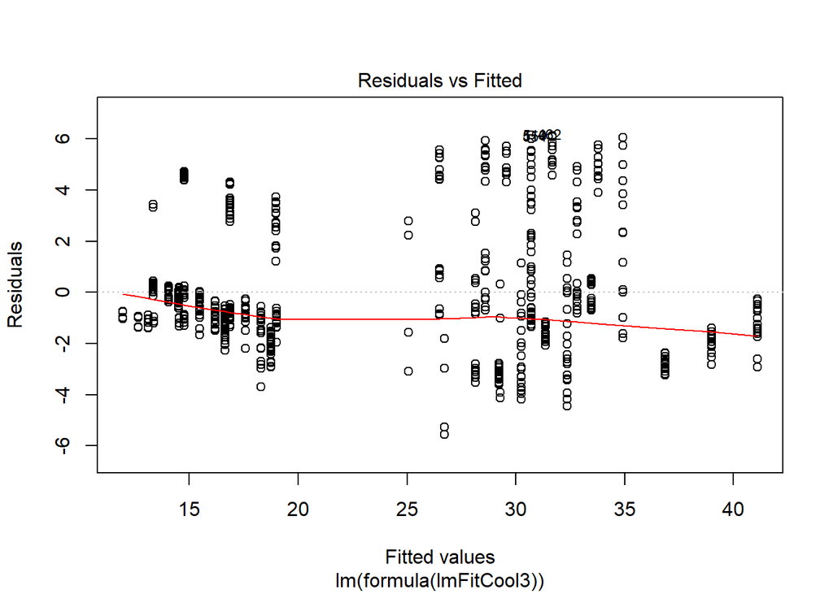

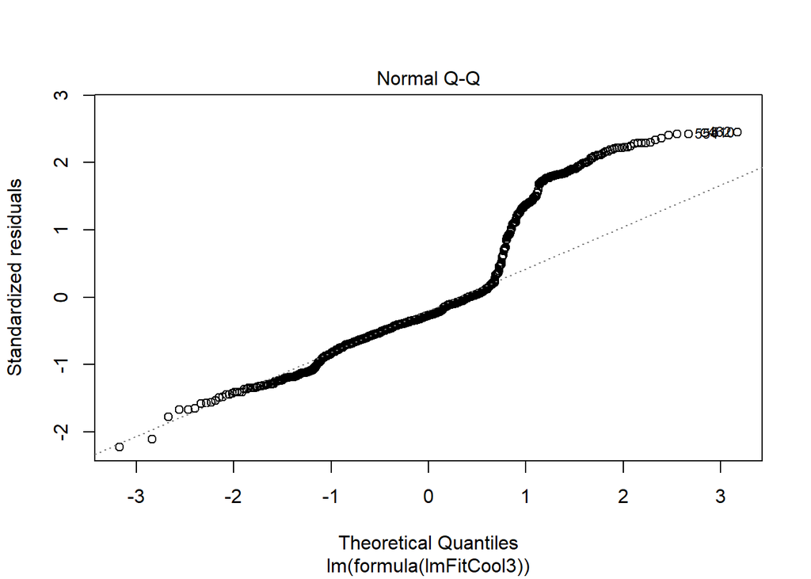

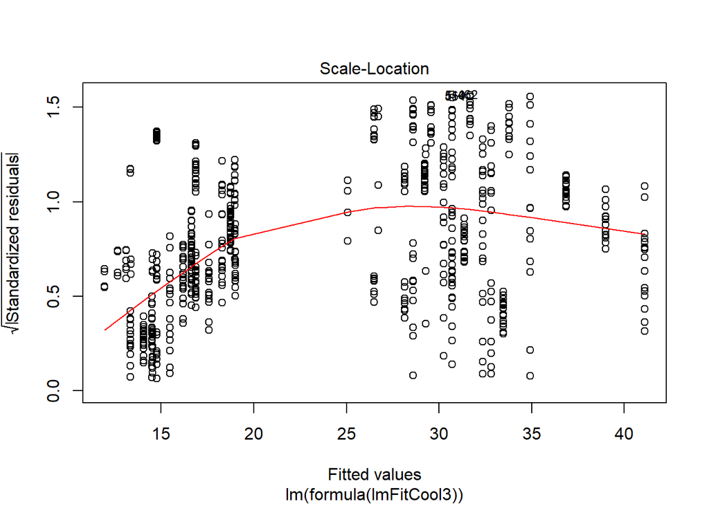

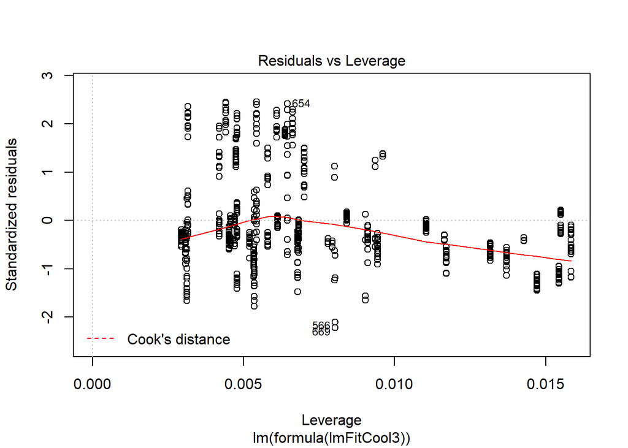

```r
plot(lmFitCool)
```

Perform linear regression on Heating Load vs all others to find the best model

```r
lmFitHeat1 <- lm(HeatingLoad ~ . , data = energyData)
summary(lmFitHeat1)
```

```
##
## Call:
## lm(formula = HeatingLoad ~ ., data = energyData)
##
## Residuals:
##     Min      1Q  Median      3Q     Max
## -6.1770 -0.9063 -0.0444  0.7533  6.3206
##
## Coefficients: (1 not defined because of singularities)
##               Estimate Std. Error t value Pr(>|t|)
## (Intercept)  12.465829  12.374688   1.007   0.3141
## Compactness -13.312667   6.774583  -1.965   0.0498 *
## SurfaceArea  -0.022008   0.011112  -1.981   0.0480 *
## WallArea      0.027552   0.004388   6.279 6.01e-10 ***
## RoofArea            NA         NA      NA       NA
## Height        1.060263   0.233924   4.533 6.87e-06 ***
## Orientation  -0.088424   0.060854  -1.453   0.1467
## GlazingArea   9.042753   0.607969  14.874  < 2e-16 ***
## GAreaDist     0.195144   0.045161   4.321 1.78e-05 ***
## CoolingLoad   0.735366   0.021253  34.601  < 2e-16 ***
## ---
## Signif. codes:  0 '***' 0.001 '**' 0.01 '*' 0.05 '.' 0.1 ' ' 1
##
## Residual standard error: 1.796 on 691 degrees of freedom
## Multiple R-squared:  0.9684, Adjusted R-squared:  0.9681
## F-statistic:  2650 on 8 and 691 DF,  p-value: < 2.2e-16
```

```r
lmFitHeat2 <- update(lmFitHeat1, ~ . - Orientation - Compactness - RoofArea - CoolingLoad, data = energyData)
summary(lmFitHeat2)
```

```
##
## Call:
## lm(formula = HeatingLoad ~ SurfaceArea + WallArea + Height +
##     GlazingArea + GAreaDist, data = energyData)
##
## Residuals:
##     Min      1Q  Median      3Q     Max
## -9.7033 -1.5362  0.0769  1.5652  7.9039
##
## Coefficients:
##               Estimate Std. Error t value Pr(>|t|)
## (Intercept) -35.312919   3.556602  -9.929  < 2e-16 ***
## SurfaceArea   0.016936   0.005487   3.086  0.00211 **
## WallArea      0.036263   0.005928   6.117 1.59e-09 ***
## Height        5.581899   0.280517  19.899  < 2e-16 ***
## GlazingArea  19.933716   0.882546  22.587  < 2e-16 ***
## GAreaDist     0.236050   0.076384   3.090  0.00208 **
## ---
## Signif. codes:  0 '***' 0.001 '**' 0.01 '*' 0.05 '.' 0.1 ' ' 1
##
## Residual standard error: 3.042 on 694 degrees of freedom
## Multiple R-squared:  0.9091, Adjusted R-squared:  0.9084
## F-statistic:  1387 on 5 and 694 DF,  p-value: < 2.2e-16
```

```r
cd <- cooks.distance(lmFitHeat2)
energyData.clean <- energyData[abs(cd) < 4/nrow(energyData), ]
nrow(energyData.clean)
```

```
## [1] 640
```

```r
formula(lmFitHeat2)
```

```
## HeatingLoad ~ SurfaceArea + WallArea + Height + GlazingArea +
##     GAreaDist
```

```r
lmFitHeat <- lm(formula(lmFitHeat2), data = energyData.clean)
```

```r
summary
```

```
## function (object, ...)
## UseMethod("summary")
## <bytecode: 0x000000001b6a9ed0>
## <environment: namespace:base>
```

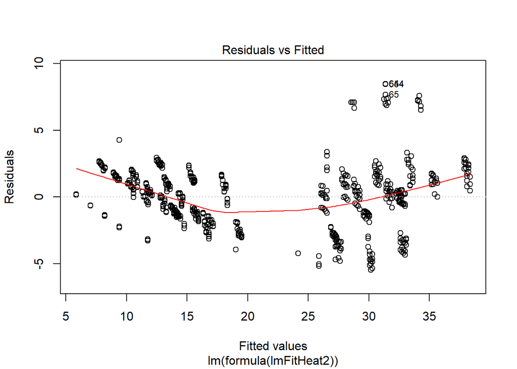

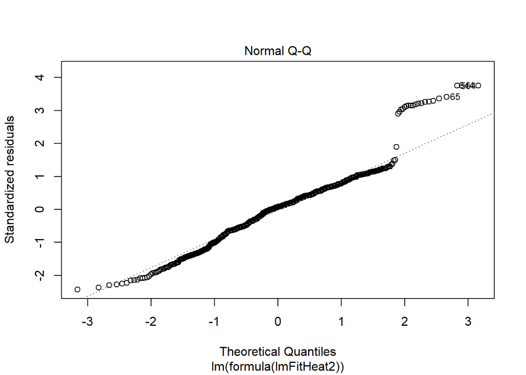

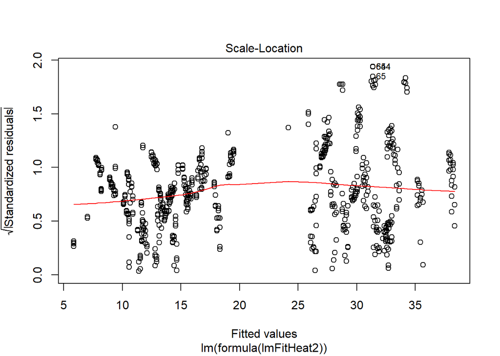

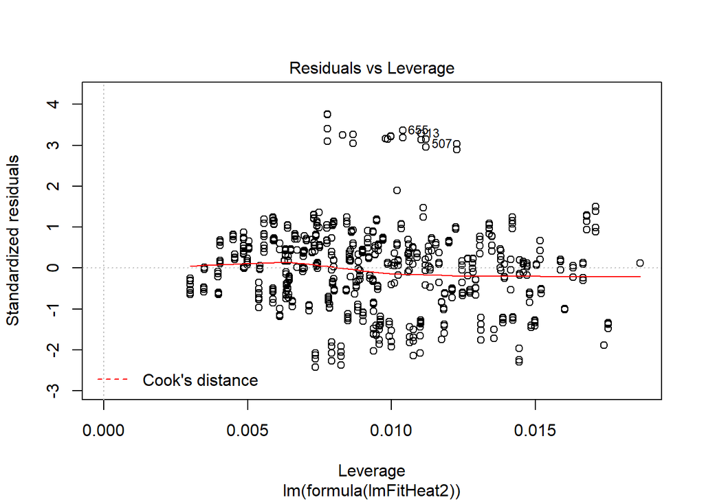

```r
plot(lmFitHeat)
```

## Prediction of Energy Efficiency

Import the CSV data file `assign1_EnergyPred.csv` for Prediction and quckly get the structure of the data.

```r
energyPred <- read.csv2("assign1_EnergyPred.csv", header = TRUE)
str(energyPred)
```

```
## 'data.frame':    10 obs. of  1 variable:
##  $ Compactness.SurfaceArea.WallArea.RoofArea.Height.Orientation.GlazingArea.GAreaDist: Factor w/ 10 levels "0.66,759.5,318.5,220.5,3.5,4,0.4,5",..: 4 1 5 10 7 6 8 3 2 9
```

To start, get the first few rows of data and display it.

```r
head(energyPred,3)
```

```
##   Compactness.SurfaceArea.WallArea.RoofArea.Height.Orientation.GlazingArea.GAreaDist
## 1                                                     0.69,735,294,220.5,3.5,2,0.1,3
## 2                                                 0.66,759.5,318.5,220.5,3.5,4,0.4,5
## 3                                                     0.74,686,245,220.5,3.5,2,0.1,1
```

Also, get the last few rows of data and display it.

```r
tail(energyPred)
```

```
##    Compactness.SurfaceArea.WallArea.RoofArea.Height.Orientation.GlazingArea.GAreaDist
## 5                                                    0.76,661.5,416.5,122.5,7,3,0.4,5
## 6                                                   0.76,661.5,416.5,122.5,7,3,0.25,5
## 7                                                         0.79,637,343,147,7,5,0.25,2
## 8                                                  0.66,759.5,318.5,220.5,3.5,5,0.4,1
## 9                                                  0.66,759.5,318.5,220.5,3.5,5,0.1,1
## 10                                                    0.9,563.5,318.5,122.5,7,3,0.4,1
```

Then, get the summary of the dataset.

```r
summary (energyData.clean)
```

```
##   Compactness      SurfaceArea       WallArea        RoofArea
##  Min.   :0.6200   Min.   :514.5   Min.   :245.0   Min.   :110.2
##  1st Qu.:0.6600   1st Qu.:588.0   1st Qu.:294.0   1st Qu.:147.0
##  Median :0.7400   Median :686.0   Median :318.5   Median :220.5
##  Mean   :0.7588   Mean   :677.0   Mean   :316.4   Mean   :180.3
##  3rd Qu.:0.8600   3rd Qu.:759.5   3rd Qu.:343.0   3rd Qu.:220.5
##  Max.   :0.9800   Max.   :808.5   Max.   :416.5   Max.   :220.5
##      Height       Orientation     GlazingArea       GAreaDist
##  Min.   :3.500   Min.   :2.000   Min.   :0.0000   Min.   :0.000
##  1st Qu.:3.500   1st Qu.:3.000   1st Qu.:0.1000   1st Qu.:2.000
##  Median :3.500   Median :3.000   Median :0.2500   Median :3.000
##  Mean   :5.075   Mean   :3.492   Mean   :0.2395   Mean   :2.861
##  3rd Qu.:7.000   3rd Qu.:4.000   3rd Qu.:0.4000   3rd Qu.:4.000
##  Max.   :7.000   Max.   :5.000   Max.   :0.4000   Max.   :5.000
##   HeatingLoad     CoolingLoad
##  Min.   : 6.01   Min.   :10.90
##  1st Qu.:12.93   1st Qu.:15.44
##  Median :16.96   Median :20.11
##  Mean   :21.24   Mean   :23.60
##  3rd Qu.:29.49   3rd Qu.:31.70
##  Max.   :41.73   Max.   :47.59
```

```r
summary(energyPred)
```

```
##  Compactness.SurfaceArea.WallArea.RoofArea.Height.Orientation.GlazingArea.GAreaDist
##  0.66,759.5,318.5,220.5,3.5,4,0.4,5:1
##  0.66,759.5,318.5,220.5,3.5,5,0.1,1:1
##  0.66,759.5,318.5,220.5,3.5,5,0.4,1:1
##  0.69,735,294,220.5,3.5,2,0.1,3    :1
##  0.74,686,245,220.5,3.5,2,0.1,1    :1
##  0.76,661.5,416.5,122.5,7,3,0.25,5 :1
##  (Other)                           :4
```

Next, perform prediction based on the dataset

Based on the summary shown, the cooling load wiill be added to the dataset to obtained the best fit line. The dataset from the energyPred will cause more likely improve the sum of square errors.

# Cooling Load Prediction

```r
names(energyPred)
```

```
## [1] "Compactness.SurfaceArea.WallArea.RoofArea.Height.Orientation.GlazingArea.GAreaDist"
```

Data : Cooling Load vs all other variables

Strategy : Linear Regression ( Cooling Load vs all other variables)

Result : Obtained the best-fit (optimal) linear model by minimizing the sum of square errors

Best-Fit Line : CoolingLoad ~ SurfaceArea + WallArea + GlazingArea + I(SurfaceArea^2)

Prediction :

```r
newData <- energyData.clean[c(1,50, 100, 250, 300),]
predict(lmFitCool, newdata = newData, interval = "confidence", level = 0.95)
```

```
##          fit      lwr      upr
## 1   17.57725 17.10629 18.04821
## 54  29.23753 28.63900 29.83605
## 108 18.74340 18.20942 19.27738
## 273 18.75814 18.39729 19.11899
## 329 36.86608 36.25287 37.47930
```

```r
predict(lmFitCool, newdata = newData, interval = "prediction", level = 0.95)
```

```
##          fit      lwr      upr
## 1   17.57725 12.61968 22.53482
## 54  29.23753 24.26622 34.20883
## 108 18.74340 13.77945 23.70735
## 273 18.75814 13.80982 23.70647
## 329 36.86608 31.89298 41.83918
```

Based on the predicted dataset above, the predicted best fit value for Cooling Load is 17.57725 for minimum value and the maximum value is 36.86608. As the data is worth noting that the confidence interval is almost the same for the minimum and the maximum fit value and lwr value for Cooling Load the confidence level may note that the data is quite linear in terms of values.

# Heating Load Prediction

```r
names(energyPred)
```

```
## [1] "Compactness.SurfaceArea.WallArea.RoofArea.Height.Orientation.GlazingArea.GAreaDist"
```

Data : Heating Load vs all other variables

Strategy : Linear Regression ( Heating Load vs all other variables)

Result : Obtained the best fit linear model

Best-Fit Line : HeatingLoad ~ SurfaceArea + WallArea + Height + GlazingArea + GAreaDist

Prediction :

```r
newDataHeat <- energyData.clean[c(1,50, 100, 250, 300),]
predict(lmFitHeat, newdata = newData, interval = "confidence", level = 0.95)
```

```
##          fit      lwr      upr
## 1   13.35563 12.94514 13.76613
## 54  26.87225 26.31007 27.43443
## 108 19.37876 18.95691 19.80062
## 273 15.83659 15.49583 16.17734
## 329 32.63048 32.12737 33.13360
```

```r
predict(lmFitHeat, newdata = newData, interval = "prediction", level = 0.95)
```

```
##          fit      lwr      upr
## 1   13.35563  8.89491 17.81635
## 54  26.87225 22.39502 31.34948
## 108 19.37876 14.91698 23.84055
## 273 15.83659 11.38174 20.29143
## 329 32.63048 28.16029 37.10068
```

The Heating Load dataset values for fit values is the same for confidence level and prediction level but different for the lwr and upr values. This means that the Heating Load needs to be added after few data sets for the confidence level and prediction level in order for the model to be linear or best fit.

## Conclusion

Heating Load is the amount of heat energy that would need to be *added* to a space to maintain the temperature in an acceptable range. Cooling Load is the amount of heat energy that would need to be *removed* from a space (cooling) to maintain the temperature in an acceptable range. Thus, it is important in Civil Engineering to estimate the Heating and Cooling Load of a building while designing/planning the structure.